# ex_baysianABTest

gingi99

2019-02-13

# 1 Summary

- Bayesian AB Testの練習
  - 参考 : http://rtokei.tech/stan/bayesian-inference-with-stan-038/
- CVRのデータ例をもとに、CVRが二項分布のもとで生成されているとみなして、ベイジアンABテストを行う
  - 参考サイトどおりの結果にならなかったけど
- bayesAB パッケージを使う
  - ベルヌーイ分布の例をそのまま写景実行
  - 他の例もいくつかありそう : https://charleshsliao.wordpress.com/2017/03/13/ab-testing-with-bayesab/

# 2 Preparations

## 2.1 libraries

```r
options(scipen=10)
set.seed(1234)

library(knitr)
library(dplyr)
library(ggplot2)

library(rstan)
library(bayesAB)
```

# 3 Bayesian AB Test by Stan

## 3.1 Data Create

```r
data.frame(date = c(as.Date("2017-05-23"),as.Date("2017-05-23"),as.Date("2017-05-24"),as.Date("2017-05-24"),as.Date("2017-05-25"),
                    as.Date("2017-05-25"),as.Date("2017-05-26"),as.Date("2017-05-26"),as.Date("2017-05-27"),as.Date("2017-05-27"),
                    as.Date("2017-05-28"),as.Date("2017-05-28"),as.Date("2017-05-29"),as.Date("2017-05-29"),as.Date("2017-05-30"),
                    as.Date("2017-05-30"),as.Date("2017-05-31"),as.Date("2017-05-31")),
           pattern = rep(c("Red","Blue"),9),
           UUPV = c(193,232,1127,1129,1145,1008,1108,1107,1241,959,1128,1216,1194,1082,1171,1065,1084,979),
           CV = c(23,18,114,104,133,101,113,119,135,85,99,99,123,112,110,105,124,112)) -> df
df$CVR <- df$CV / df$UUPV
```

## 3.2 Data Check

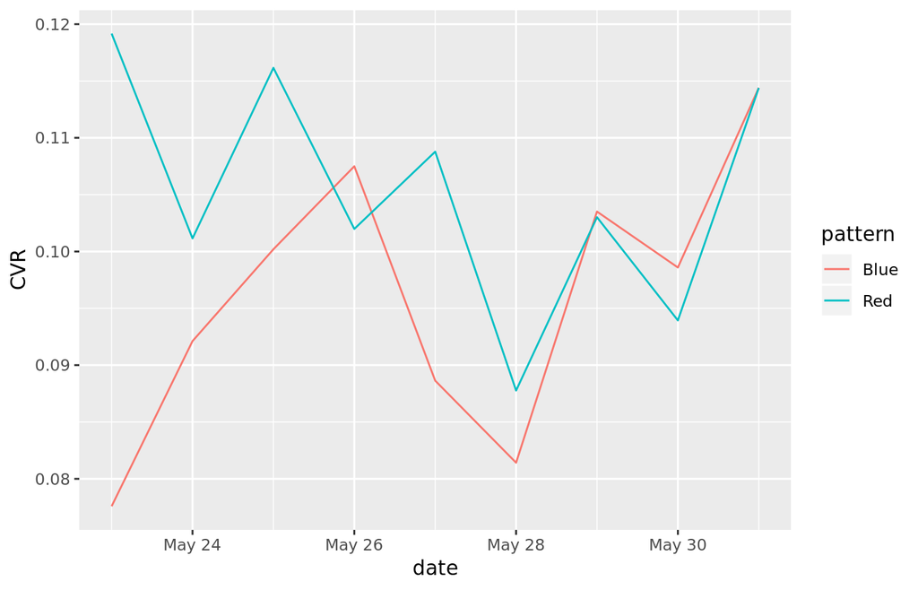

```r
df %>%
  ggplot(aes(x = date, y = CVR, color = pattern)) +
  geom_line()
```

## 3.3 Stan Prep

```r
df.blue <- df %>% filter(pattern == "Blue")
df.red <- df %>% filter(pattern == "Red")

standata <-list(N_B = nrow(df.blue),
                K_B = df.blue$UUPV,
                Y_B = df.blue$CV,
                N_R = nrow(df.red),
                K_R = df.red$UUPV,
                Y_R = df.red$CV)
```

## 3.4 Stan Code

```r
stancode <- "
data{
  int N_B;
  int K_B[N_B];
  int Y_B[N_B];
  int N_R;
  int K_R[N_R];
  int Y_R[N_R];
}

parameters{
  real<lower=0, upper=1> p_B;
  real<lower=0, upper=1> p_R;
}

model{
  p_B ~ beta(1, 1); #事前分布あれば…
  p_R ~ beta(1, 1);

  for(n in 1:N_B){
    Y_B[n] ~ binomial(K_B[n], p_B);
  }

  for(n in 1:N_R){
    Y_R[n] ~ binomial(K_R[n], p_R);
  }
}

generated quantities{
  real delta;
  real ImpRate;
  real delta_over1;
  real delta_over2;
  real delta_over3;

  delta = p_B - p_R;
  ImpRate = (p_B - p_R)/p_R;
  delta_over1 = step(delta);
  delta_over2 = delta > 0.01 ? 1 : 0;
  delta_over3 = delta > 0.02 ? 1 : 0;
}
"
```

## 3.5 Stan Run

```r
fit <- stan(model_code = stancode, iter = 4000, chains = 4, data = standata)
```

```
## DIAGNOSTIC(S) FROM PARSER:
## Info (non-fatal): Comments beginning with # are deprecated.  Please use // in place of # for line comments.
##
##
##
##
##
```

## 3.6 Result

```r
round(summary(fit)$summary, digits = 3)
```

```
##                  mean se_mean    sd      2.5%       25%       50%
## p_B             0.098   0.000 0.003     0.091     0.095     0.098
## p_R             0.104   0.000 0.003     0.098     0.102     0.104
## delta          -0.006   0.000 0.004    -0.015    -0.009    -0.006
## ImpRate        -0.059   0.000 0.041    -0.139    -0.087    -0.061
## delta_over1     0.074   0.004 0.263     0.000     0.000     0.000
## delta_over2     0.000     NaN 0.000     0.000     0.000     0.000
## delta_over3     0.000     NaN 0.000     0.000     0.000     0.000
## lp__        -5937.653   0.017 0.970 -5940.226 -5938.039 -5937.362
##                   75%     97.5%    n_eff  Rhat
## p_B             0.100     0.104 7340.463 1.000
## p_R             0.106     0.110 7412.622 1.000
## delta          -0.003     0.002 7469.968 1.000
## ImpRate        -0.032     0.023 7430.856 1.000
## delta_over1     0.000     1.000 5045.908 1.000
## delta_over2     0.000     0.000      NaN   NaN
## delta_over3     0.000     0.000      NaN   NaN
## lp__        -5936.952 -5936.702 3326.554 1.001
```

# 4 Bayesian AB Test by bayesAB - Bernouli Distribution

bayesAB パッケージを用いたベイジアンABテスト

## 4.1 Data Prep

ベルヌーイ分布にしたがって、0 or 1が出るシミュレーションデータを作成

- Aは250人のうち、25%の確率でクリックしたデータとみなす
- Bは250人のうち、20%の確率でクリックしたデータとみなす

```r
A_binom <- rbinom(250, 1, .25)
B_binom <- rbinom(250, 1, .2)
```

## 4.2 Data Check

```r
str(A_binom)
```

```
##  int [1:250] 0 0 0 0 0 1 0 0 0 0 ...
```

```r
table(A_binom)
```

```
## A_binom
##   0   1
## 188  62
```

```r
table(B_binom)
```

```
## B_binom
##   0   1
## 201  49
```

## 4.3 Prior distribution

ベルヌーイ分布の事前分布として、ベータ分布を用いる

ベルヌーイ分布のパラメータpが0.2-0.3付近にあると経験から知っていると想定

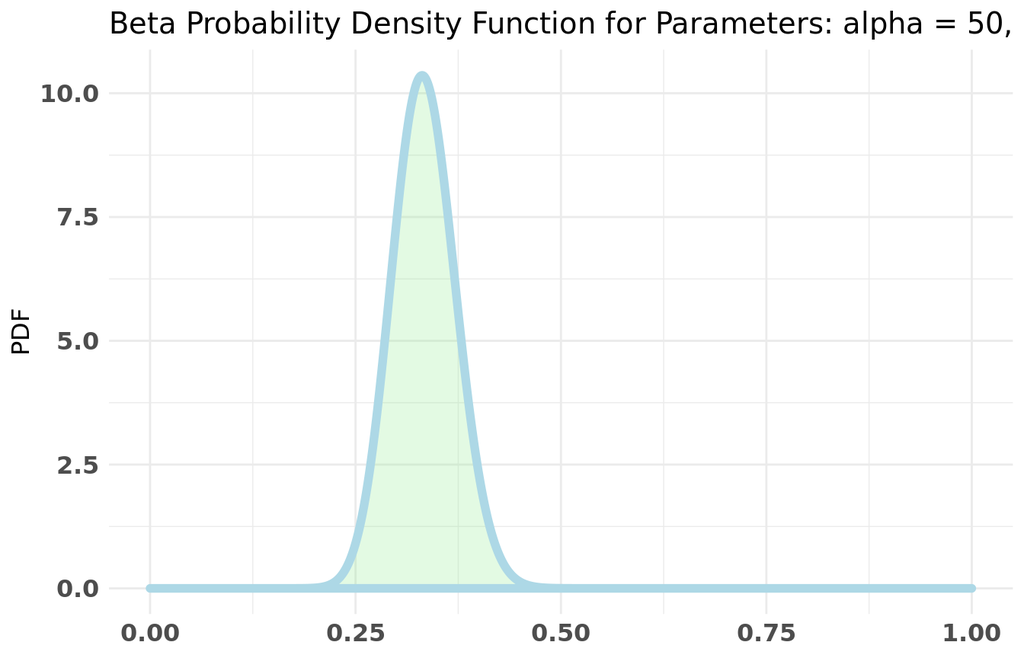

```r
# pが50 / 150 = 0.3333
bayesAB::plotBeta(50, 100)
```

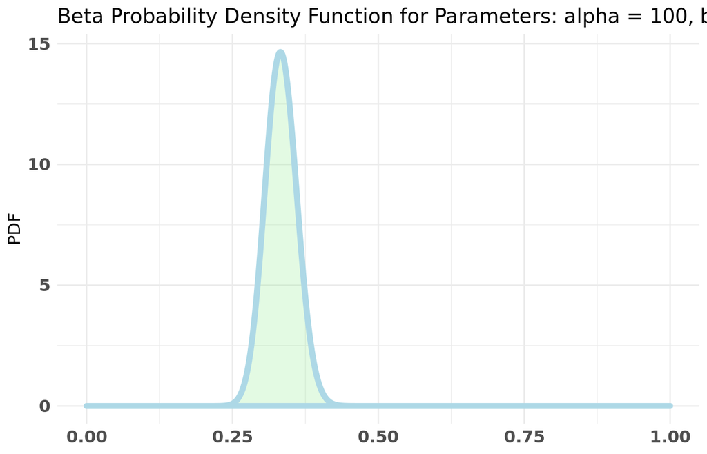

```r
bayesAB::plotBeta(100, 200)
```

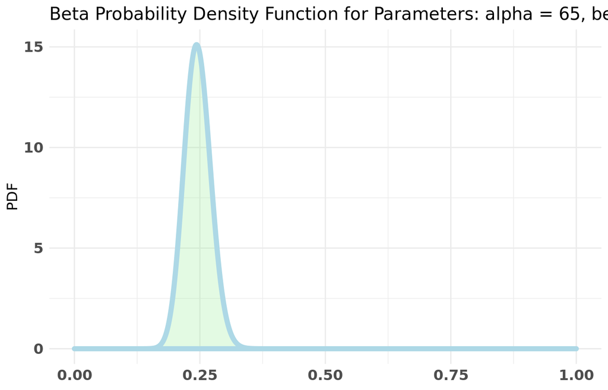

```r
# pが65/(65+200) = 0.245
bayesAB::plotBeta(65, 200)
```

## 4.4 Inference

- print は入力したパラメータの情報を出力してるのみ
  - AカラムのMeanは入力したA_binomの平均値のこと
- summaryは計算結果
  - 1行目 : ベルヌーイ分布のパラメータpの事後分布のQuantile値。pがどれくらい揺れそうか分かる。
  - 2行目 : AがBより大きい確率。基本はこれを見て判断
  - 3行目 : (A-B)/Bの確信区間。Plotの3つ目の5%から95%と対応
  - 4行目 : 事後期待値損失。解釈の仕方は…？

```r
AB <- bayesTest(A_binom, B_binom,
                priors = c("alpha" = 65, "beta" = 200),
                n_samples = 10000, # default 1e5
                distribution = "bernoulli")

print(AB)
```

```
## --------------------------------------------
## Distribution used: bernoulli
## --------------------------------------------
## Using data with the following properties:
##             A     B
## Min.    0.000 0.000
## 1st Qu. 0.000 0.000
## Median  0.000 0.000
## Mean    0.248 0.196
## 3rd Qu. 0.000 0.000
## Max.    1.000 1.000
## --------------------------------------------
## Conjugate Prior Distribution: Beta
## Conjugate Prior Parameters:
## $alpha
## [1] 65
##
## $beta
## [1] 200
##
## --------------------------------------------
## Calculated posteriors for the following parameters:
## Probability
## --------------------------------------------
## Monte Carlo samples generated per posterior:
## [1] 10000
```

```r
summary(AB)
```

```
## Quantiles of posteriors for A and B:
##
## $Probability
## $Probability$A
##        0%       25%       50%       75%      100%
## 0.1787758 0.2339868 0.2466452 0.2593952 0.3271814
##
## $Probability$B
##        0%       25%       50%       75%      100%
## 0.1602745 0.2085256 0.2206834 0.2335702 0.2997344
##
##
## --------------------------------------------
##
## P(A > B) by (0)%:
##
## $Probability
## [1] 0.8362
##
## --------------------------------------------
##
## Credible Interval on (A - B) / B for interval length(s) (0.9) :
##
## $Probability
##          5%         95%
## -0.07272528  0.34169292
##
## --------------------------------------------
##
## Posterior Expected Loss for choosing B over A:
##
## $Probability
## [1] 0.01029771
```

## 4.5 Plot

- 1つ目 : 事前分布（つまりベータ分布）
- 2つ目 : パラメータpの事後分布
- 3つ目 : 10000個のサンプルのヒストグラム。summaryの2つ目の結果と対応している

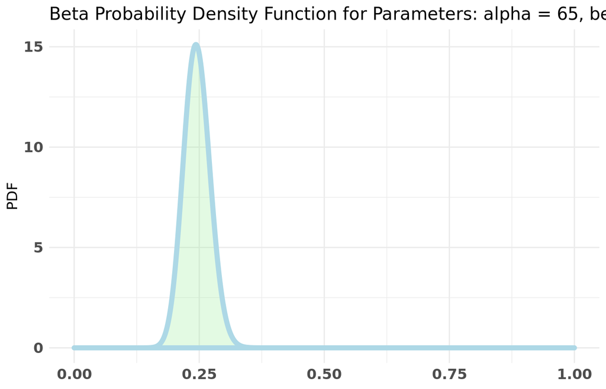

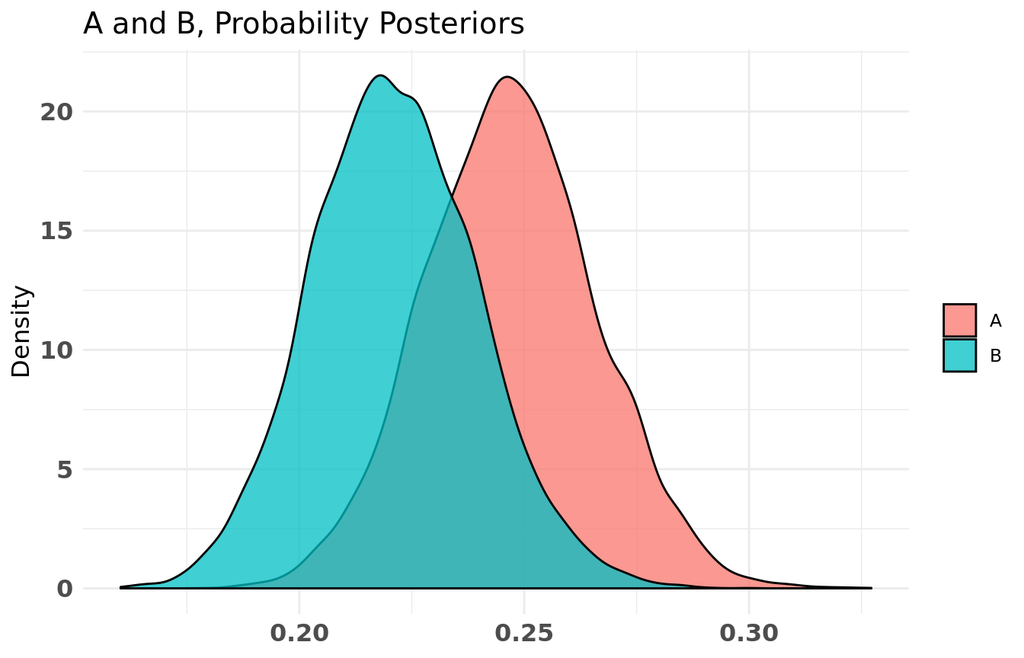

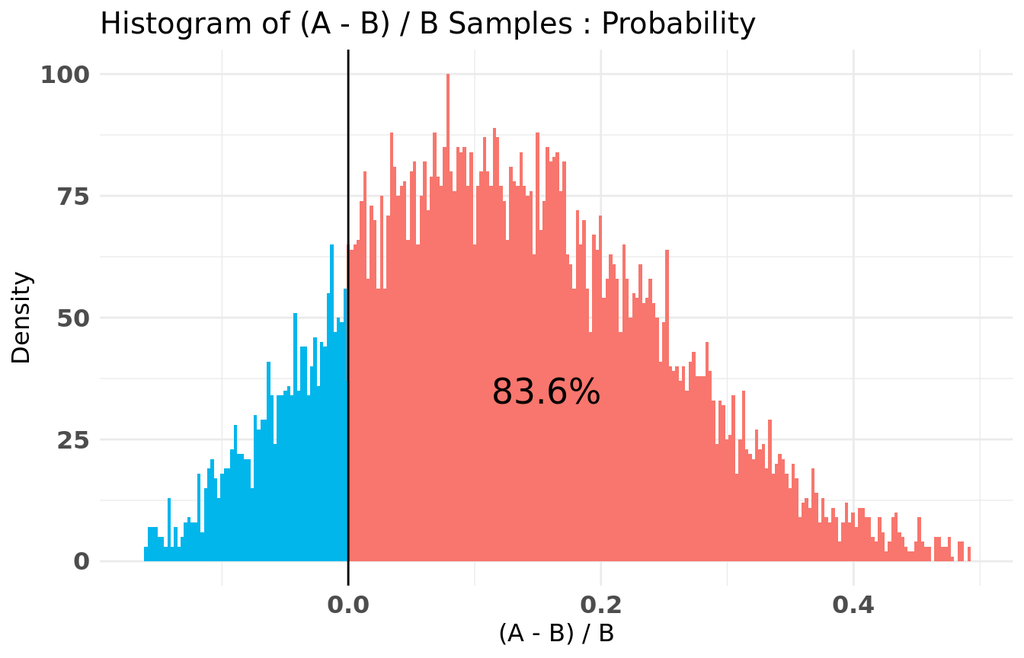

```r
plot(AB)
```